# From Messy Data to Clean Maps

# Mapping

Now for the part you came here for, MAPPING! We are going to produce one map with three steps. The first step is to plot the species densities at the different study sites. The second step is to provide a general map of the study area. And finally we will inset the maps to make one big nice one! We will use the ggplot package with some additional mapping packages. We will point them out as we go along.

```r
#First lets pull the raster data for the United States from the internet using the raster package.
us <- getData("GADM",country="USA",level=1)
# GADM' is a database of global administrative boundaries
# you must also provide the level of administrative subdivision (0=country, 1=first level subdivision)

# We want to keep our study area which is in Florida. You can add states by adding them to this vector.
states <- c('Florida')
us.states <- us[us$NAME_1 %in% states,] # find the NAME_1 that matches your states
```

## 1 - Site Map

OK now lets map out sites!

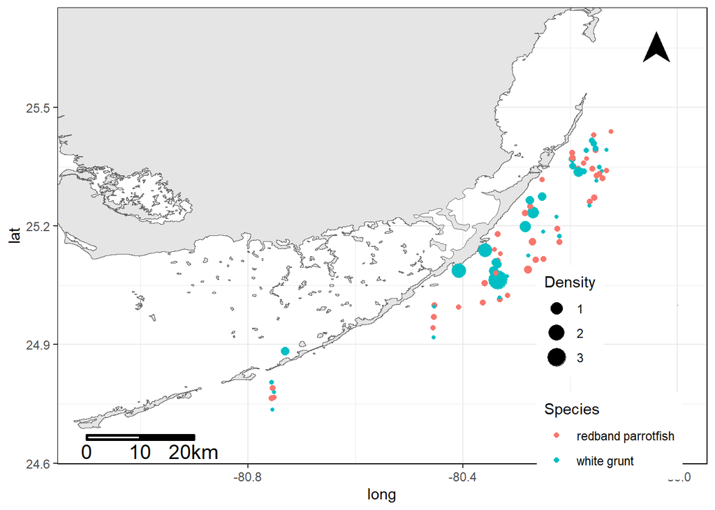

```r
# the keys are your shape polygon for Florida and your data full_summary
sites_map = ggplot()+
  geom_polygon(data = us.states,aes(x=long,y=lat,group=group), colour = 'grey40', size = 0.01,fill = 'grey90')+
  geom_jitter(data = full_summary, aes(x=Long,y=Lat, color = Species, size=Density), height = 0.05)
# Just like this the map looks crazy, lets zoom in. Its messy data so we have some weird data points also. Think about how you can filter those out. That's a hint!
sites_map =sites_map+ coord_cartesian(xlim = c(-81.1,-80.0), ylim = c(24.65,25.70))

#Every good map has a compass and a scale bar lets add them.The functions north() and scalebar are both from the package ggsn.
sites_map =sites_map+north(location = 'topright', scale = 0.9, symbol = 12, x.min = -80.09, x.max = -80.0, y.min = 25.6, y.max = 25.7)+
  scalebar(x.min = -80.80, x.max = -81.1, y.min = 24.66, y.max = 24.72, dist = 10, dist_unit = 'km', transform = TRUE, model = 'WGS84', location = "bottomleft", st.dist = 0.49, height = 0.18) #transform = TRUE assumes coordinates are in decimal degrees

# the ocean isn't grey, lets change that
sites_map =sites_map+ theme_bw()+
  theme(panel.border = element_rect(colour = 'black'))

# We also may want to play with where this legend is later
sites_map = sites_map +  theme(legend.position = c(0.85, 0.20))


sites_map
```

Great! The next one should be easy now.

## 2 - Study Area Map

Now we are making the larger map, to provide some context for the site map.

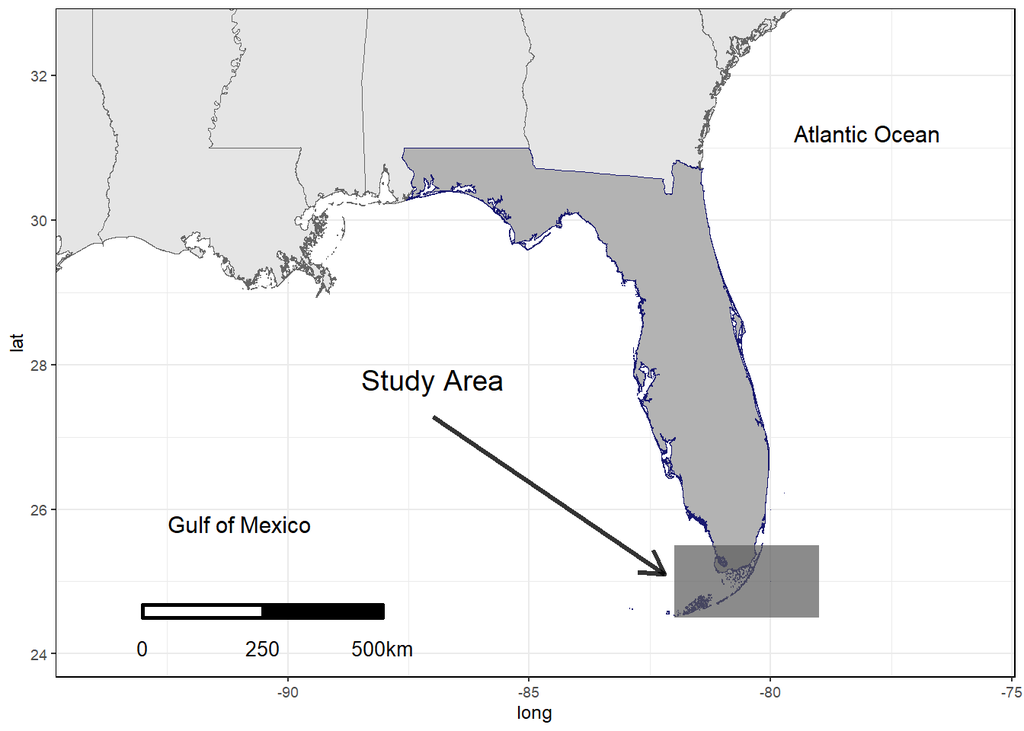

```r
# Start off the map similarly to the site map but instead of our data we will be pulling in the shape file for Florida
continent = ggplot()+
  geom_polygon(data = us,aes(x=long,y=lat,group=group), colour = 'grey40',
               size = 0.01, fill = 'grey90')+
  geom_polygon(data = us.states,aes(x=long,y=lat,group=group), colour = 'midnightblue', size = 0.01,fill = 'grey70')
# now reduce the viewing area and delimit where the research took place
continent = continent+coord_cartesian(xlim = c(-93.9,-75.85), ylim = c(24.1,32.5))

# Add in the scale bar again
continent = continent+scalebar(x.min = -93, x.max = -85, y.min = 24.5, y.max = 25.5, dist = 250, dist_unit = 'km', st.size = 3.6, #add scalebar
                    transform = TRUE, model = 'WGS84', location = 'bottomleft', st.dist = 0.42, height = 0.18) #transform = TRUE assumes coordinates are in decimal degrees

# New and specific to this study area map - add a shaded study area box
continent = continent+ annotate("rect", xmin = -79, xmax = -82, ymin = 24.5, ymax = 25.5, alpha = .7)

# Add an arrow to point to the study region
continent = continent + annotate('segment',x=-87, y=27.28, xend=-82.2, yend=25.1, arrow=arrow(length = unit(0.04, "npc")), #arrow
           alpha = 0.8, size=1.1, color="black")

# add some notation of where you are
continent = continent+ annotate('text', x = -91, y = 25.8, label = 'Gulf of Mexico', size = 4)+
  annotate('text', x = -78, y = 31.2, label = 'Atlantic Ocean', size = 4)+
  annotate('text', x = -87, y = 27.8, label = 'Study Area', size = 5)

# Change the background of things
continent = continent+ theme_bw(base_size = 9) + # black and white theme, gets rid of grey background
  theme(panel.background = element_rect(fill= 'white',color = 'white')) +
  theme(panel.border = element_rect(colour = 'black'))

continent
```

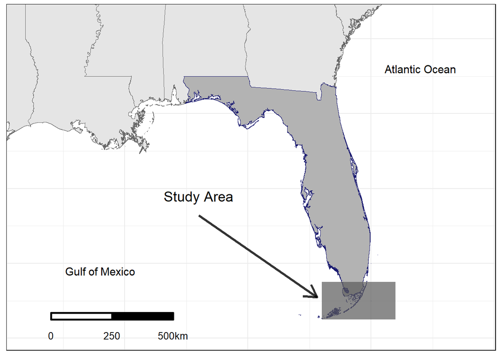

```r
## You can add these arguments to your plot to clean up the edges of the map for final print
continent +
  theme(axis.ticks = element_blank())+
  theme(axis.text.x = element_blank()) +
  theme(axis.text.y = element_blank()) +
  theme(axis.title.x = element_blank()) +
  theme(axis.title.y = element_blank())
```

## 3 - Inset the Maps

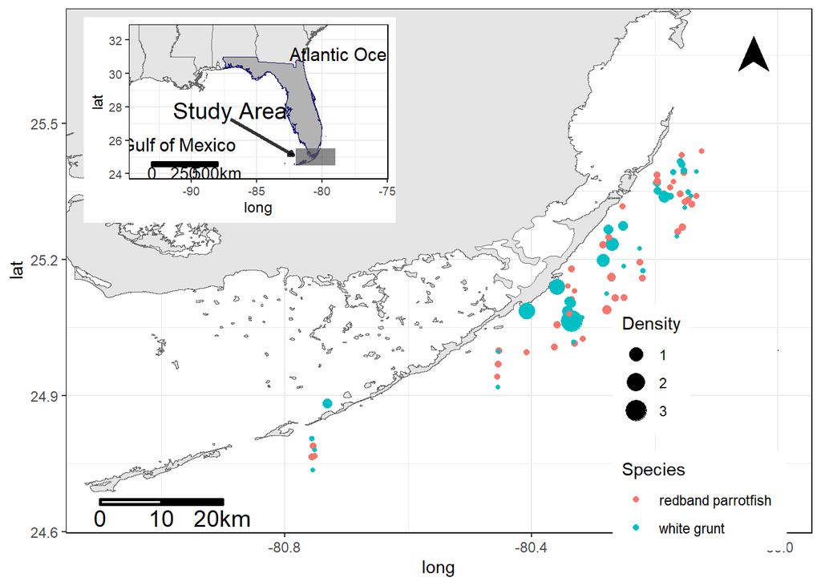

```r
# this just draws the maps on top of one another
insetmap = ggdraw()+
  draw_plot(sites_map) +
  draw_plot(continent)

# doesn't look right, right? Now you have to work with dimensions for the 2nd map. See below: x,y, width, and height for the continent/study area map

insetmap = ggdraw()+
  draw_plot(sites_map) +
  draw_plot(continent, x=0.102, y=0.62, width=0.38, height=0.35)

# Lets see what it looks like
insetmap # You can look at it, but it won't look good until you print it
```

```r
# Use the function ggsave to output your map. Make sure you know where it is being saved to.
ggsave('study_map.png', plot = insetmap,
       width = 8, height = 7.5,
       dpi = 300)
```

That’s all folks!

For more practice, attempt to map the answer to the question of how reef type influences fish density.

# Final ProTips

1. Comment your code! ( Use the hashtag - # )
2. R is case-sensitive. For example, “head()” is not the same as “Head().”
3. Be smart when naming files, folders, etc., you will be looking for them later. Adding the date or sequential numbers to a folder name is helpful.
4. Debugging is the hardest part. Copy the error you get and google it. The [Stack Overflow](https://stackoverflow.com) community will be your best friend.
5. There are a million ways to skin a cat! What we showed you here is only one way of using R to do the things we want to do. Find what works for you.